# Quick Intro to TidyModels

Author

Jay Cao

Published

April 1, 2024

## Intro

Some of you are currently working on projects involving R and machine learning models. The new Tidymodels framework could be an additional useful concept to know for your projects. This notebook will give you a quick intro to Tidymodels.

So far, we have learned data wrangling using the Tidyverse eco-system. Tidymodels is to modeling what Tidyverse is to data wrangling. Tidymodels itself doesn’t implement any statistical or machine learning models. It’s a framework to organize all the tasks around modeling.

> The tidymodels framework is a collection of packages for modeling and machine learning using tidyverse principles.

> -[Tidymodels Developers](https://www.tidymodels.org/)

Below are a few core tidymodels packages.

- [tidymodels](https://www.tidymodels.org/): a meta-package that installs and load all tidymodels core packages.
- [rsample](https://rsample.tidymodels.org/): handles data splitting (e.g. for training, validation and testing) and resampling (e.g. for bootstrapping).
- [parsnip](https://parsnip.tidymodels.org/): a unified interface to different underlying R modeling packages
- [recipes](https://recipes.tidymodels.org/): an interface to data pre-processing (i.e. feature engineering)
- [workflows](https://workflows.tidymodels.org/): bundles pre-processing, modeling and post-processing together
- [tune](https://tune.tidymodels.org/): helps with hyper-parameter tuning
- [yardstick](https://yardstick.tidymodels.org/): measures model performance

This notebook will introduce you Tidymodels through an example. The workflow in this example closely follows the [case study](https://www.tidymodels.org/start/case-study/) in the official Tidymodels *Get Started* document. However, we will use a different dataset.

## Predictive Modeling with Tidymodels

### Import Data

We will use the German Credit Data for this exercise. The goal is to classify customers as good or bad credit risk based on their attributes.

Let’s first load some R packages.

```r
library(tidyverse)
library(tidymodels)

library(glmnet)     # for logistic regression
library(ranger)     # for random forest
library(vip)        # for variable importance plots
```

```r
data_url <- "http://archive.ics.uci.edu/ml/machine-learning-databases/statlog/german/german.data"

# the data file doesn't contain column names so add them
col_names <- c("chk_acct", "duration", "credit_his",
               "purpose", "amount", "saving_acct",
               "present_emp", "installment_rate",
               "sex", "other_debtor", "present_resid",
               "property", "age", "other_install",
               "housing", "n_credits", "job",
               "n_people", "telephone", "foreign",
               "response")

german_credit <- read_delim(data_url, " ", col_names = col_names) %>%
  mutate_if(is.character, as.factor) %>%     # turn all character cols to factors/categorical variables
  mutate(response = as_factor(response - 1)) %>%     # 0: good credit; 1: bad credit
  mutate(response = fct_relevel(response, c("1", "0")))     # reorder factor level so 1/bad will be the "event"

# take a look at the data
glimpse(german_credit)
## Rows: 1,000
## Columns: 21
## $ chk_acct         <fct> A11, A12, A14, A11, A11, A14, A14, A12, A14, A12, A12…
## $ duration         <dbl> 6, 48, 12, 42, 24, 36, 24, 36, 12, 30, 12, 48, 12, 24…
## $ credit_his       <fct> A34, A32, A34, A32, A33, A32, A32, A32, A32, A34, A32…
## $ purpose          <fct> A43, A43, A46, A42, A40, A46, A42, A41, A43, A40, A40…
## $ amount           <dbl> 1169, 5951, 2096, 7882, 4870, 9055, 2835, 6948, 3059,…
## $ saving_acct      <fct> A65, A61, A61, A61, A61, A65, A63, A61, A64, A61, A61…
## $ present_emp      <fct> A75, A73, A74, A74, A73, A73, A75, A73, A74, A71, A72…
## $ installment_rate <dbl> 4, 2, 2, 2, 3, 2, 3, 2, 2, 4, 3, 3, 1, 4, 2, 4, 4, 2,…
## $ sex              <fct> A93, A92, A93, A93, A93, A93, A93, A93, A91, A94, A92…
## $ other_debtor     <fct> A101, A101, A101, A103, A101, A101, A101, A101, A101,…
## $ present_resid    <dbl> 4, 2, 3, 4, 4, 4, 4, 2, 4, 2, 1, 4, 1, 4, 4, 2, 4, 3,…
## $ property         <fct> A121, A121, A121, A122, A124, A124, A122, A123, A121,…
## $ age              <dbl> 67, 22, 49, 45, 53, 35, 53, 35, 61, 28, 25, 24, 22, 6…
## $ other_install    <fct> A143, A143, A143, A143, A143, A143, A143, A143, A143,…
## $ housing          <fct> A152, A152, A152, A153, A153, A153, A152, A151, A152,…
## $ n_credits        <dbl> 2, 1, 1, 1, 2, 1, 1, 1, 1, 2, 1, 1, 1, 2, 1, 1, 2, 3,…
## $ job              <fct> A173, A173, A172, A173, A173, A172, A173, A174, A172,…
## $ n_people         <dbl> 1, 1, 2, 2, 2, 2, 1, 1, 1, 1, 1, 1, 1, 1, 1, 1, 1, 1,…
## $ telephone        <fct> A192, A191, A191, A191, A191, A192, A191, A192, A191,…
## $ foreign          <fct> A201, A201, A201, A201, A201, A201, A201, A201, A201,…
## $ response         <fct> 0, 1, 0, 0, 1, 0, 0, 0, 0, 1, 1, 1, 0, 1, 0, 1, 0, 0,…
```

### Split Data

Let’s split the data for training, validation, and testing. The `response` variable is slightly imbalanced, so we use stratified random sample. This is done with the help of Tidymodels **rsample** package.

```r
# the response variable is slightly imbalanced
german_credit %>%
  count(response) %>%
  mutate(prop = n/sum(n))
## # A tibble: 2 × 3
##   response     n  prop
##   <fct>    <int> <dbl>
## 1 1          300   0.3
## 2 0          700   0.7

# set random seed for reproducibility
set.seed(123)

# use stratified random sample
# test and non-test split
splits <- initial_split(german_credit, strata = response)
splits
## <Training/Testing/Total>
## <750/250/1000>

# retrieving data from the split data
credit_other <- training(splits)
credit_test  <- testing(splits)

# training and validation split on non-test data
val_set <- validation_split(credit_other,
                            strata = response,
                            prop = 0.80)
val_set
## # Validation Set Split (0.8/0.2)  using stratification
## # A tibble: 1 × 2
##   splits            id
##   <list>            <chr>
## 1 <split [600/150]> validation
```

### Logistic Regression

We first build a penalized logistic regression model. We will use lasso here.

Given a model such as logistic regression, Tidymodels **parsnip** package provides a unified interface (e.g. `logistic_reg()` and `set_engine()`) to different underlying modeling functions (e.g. `glmnet`, `keras` or `spark`). This is a huge advantage. Worry no more about syntax for different models from different R modeling packages.

Tidymodels **recipe** helps with pre-process data (e.g. `step_dummy`).

Tidymodels **workflows** bundles pre-processing and modeling.

```r
# build model
# note that the hyper-parameter penalty will be tuned
lr_mod <-
  logistic_reg(penalty = tune(), mixture = 1) %>%     # mixture = 1 means pure lasso
  set_engine("glmnet")     # use the glmnet

# pre-process data
lr_recipe <-
  recipe(response ~ ., data = credit_other) %>%     # response will be y/outcome
  step_dummy(all_nominal(), -all_outcomes()) %>%    # create dummies for all nominal vars excluding outcome var
  step_normalize(all_predictors())     # normalize (center and scale) all predictors

# combine modeling and data pre-processing
lr_workflow <-
  workflow() %>%
  add_model(lr_mod) %>%
  add_recipe(lr_recipe)
```

We can start to tune and train the model. We first create a grid for tuning the `penalty` hyper-parameter. We then train the model using each grid value. We use “Area under the ROC Curve” to measure model performance over the validation set, so we plot the ROC AUC measure over `penalty` grid. We then select the best model. These are all done with the help of Tidymodels **tune** package.

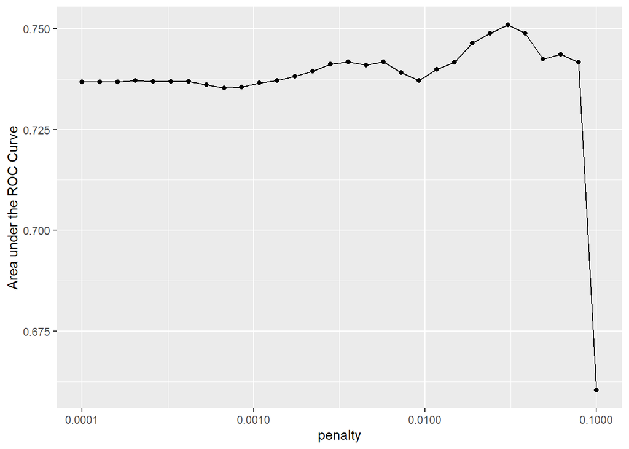

```r
# create a grid for tuning the penalty hyper-parameter
lr_reg_grid <- tibble(penalty = 10^seq(-4, -1, length.out = 30))

# train using a grid of penalty values
lr_res <-
  lr_workflow %>%
  tune_grid(val_set,
            grid = lr_reg_grid,
            control = control_grid(save_pred = TRUE),
            metrics = metric_set(roc_auc))

# plot ROC AUC against penalty grid
lr_plot <-
  lr_res %>%
  collect_metrics() %>%
  ggplot(aes(x = penalty, y = mean)) +
  geom_point() +
  geom_line() +
  ylab("Area under the ROC Curve") +
  scale_x_log10(labels = scales::label_number())

lr_plot
```

We then select the best model.

```r
# take a look at top models first
lr_res %>%
  show_best(metric = "roc_auc", n = 5)
## # A tibble: 5 × 7
##   penalty .metric .estimator  mean     n std_err .config
##     <dbl> <chr>   <chr>      <dbl> <int>   <dbl> <chr>
## 1  0.0304 roc_auc binary     0.751     1      NA Preprocessor1_Model25
## 2  0.0240 roc_auc binary     0.749     1      NA Preprocessor1_Model24
## 3  0.0386 roc_auc binary     0.749     1      NA Preprocessor1_Model26
## 4  0.0189 roc_auc binary     0.746     1      NA Preprocessor1_Model23
## 5  0.0621 roc_auc binary     0.744     1      NA Preprocessor1_Model28

# pick the top one
lr_best <-
  lr_res %>%
  select_best(metric = "roc_auc")
lr_best
## # A tibble: 1 × 2
##   penalty .config
##     <dbl> <chr>
## 1  0.0304 Preprocessor1_Model25
```

We plot the ROC for the best model we obtained from the lasso logistic regression.

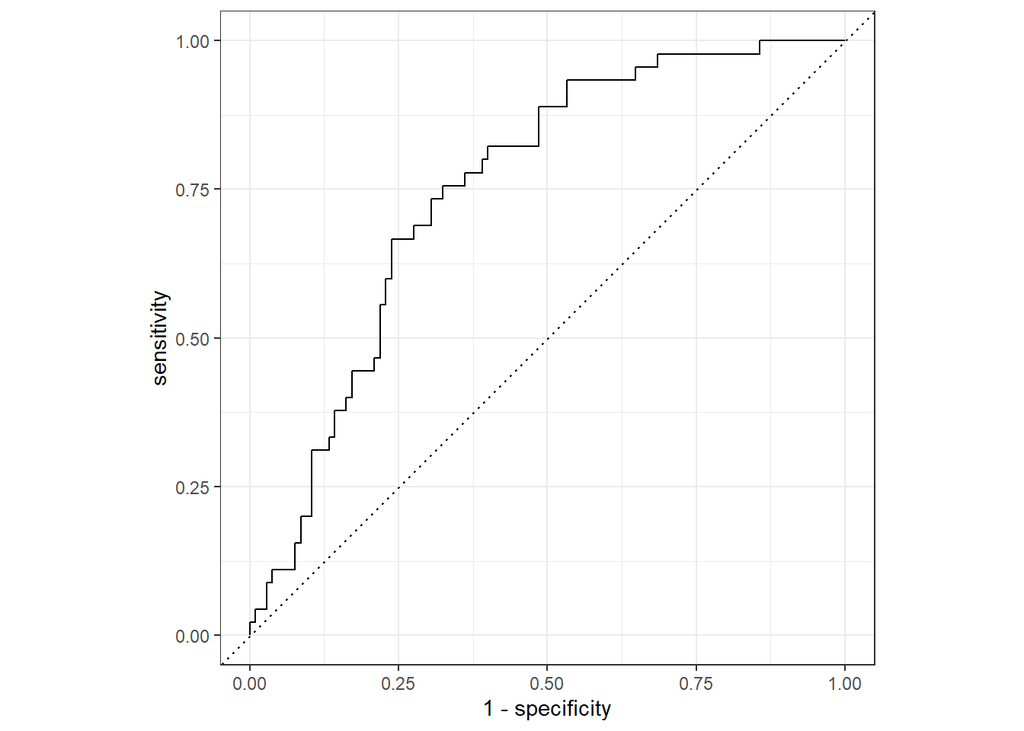

```r
lr_auc <-
  lr_res %>%
  collect_predictions(parameters = lr_best) %>%     # collect pred on val data under the best model
  roc_curve(response, .pred_1) %>%
  mutate(model = "Logistic Regression")

autoplot(lr_auc)
```

### Random Forest

We do almost exact the same thing as we did in the logistic regression except now we use random forest model.

```r
# random forest will be trained in parallel on multiple cores
# get the number of cores my computer has
cores <- parallel::detectCores()

# build a random forest model
# two hyper-parameters will be tuned
rf_mod <-
  rand_forest(mtry = tune(), min_n = tune(), trees = 30) %>%
  set_engine("ranger", num.threads = cores) %>%     # use ranger pacakge for training
  set_mode("classification")

# not much data pre-process for random forest model (just specify the model)
rf_recipe <- recipe(response ~ ., data = credit_other)

# combine model and data-process
rf_workflow <-
  workflow() %>%
  add_model(rf_mod) %>%
  add_recipe(rf_recipe)

# train and tune on validation data
# auto-create tuning grid with 25 set of values
set.seed(345)
rf_res <-
  rf_workflow %>%
  tune_grid(val_set,
            grid = 25,
            control = control_grid(save_pred = TRUE),
            metrics = metric_set(roc_auc))

# take a look at a few top models
rf_res %>%
  show_best(metric = "roc_auc")
## # A tibble: 5 × 8
##    mtry min_n .metric .estimator  mean     n std_err .config
##   <int> <int> <chr>   <chr>      <dbl> <int>   <dbl> <chr>
## 1    14    19 roc_auc binary     0.840     1      NA Preprocessor1_Model10
## 2    13    36 roc_auc binary     0.836     1      NA Preprocessor1_Model18
## 3    16    14 roc_auc binary     0.827     1      NA Preprocessor1_Model16
## 4    15    15 roc_auc binary     0.825     1      NA Preprocessor1_Model20
## 5    19    34 roc_auc binary     0.816     1      NA Preprocessor1_Model04

# select the best one
rf_best <-
  rf_res %>%
  select_best(metric = "roc_auc")
rf_best
## # A tibble: 1 × 3
##    mtry min_n .config
##   <int> <int> <chr>
## 1    14    19 Preprocessor1_Model10
```

We see the bests model has a ROC AUC of 0.840.

Plot the ROC curve together with the one obtained from the best logistic lasso model.

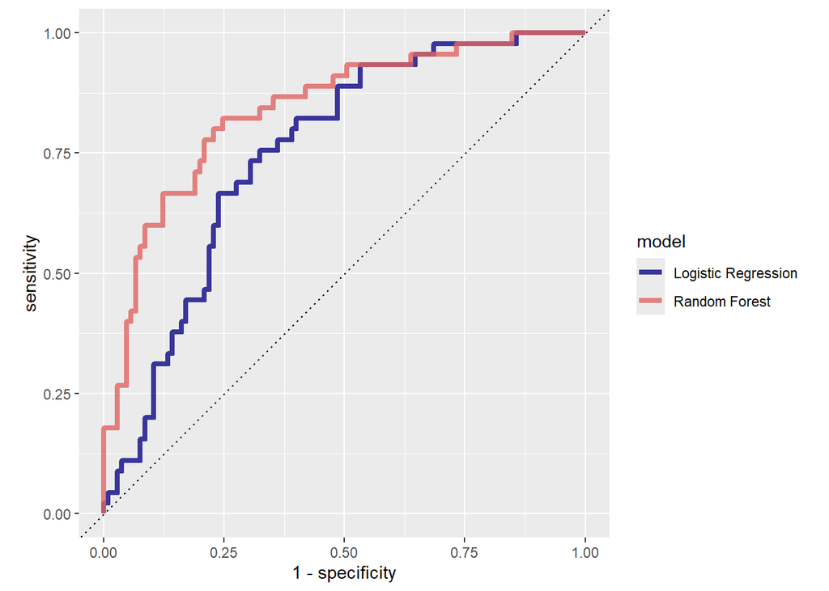

```r
rf_auc <-
  rf_res %>%
  collect_predictions(parameters = rf_best) %>% # collect pred on val data under the best model
  roc_curve(response, .pred_1) %>%
  mutate(model = "Random Forest")

# combine the ROC from the best random forest model with the one from logistic lasso
bind_rows(rf_auc, lr_auc) %>%
  ggplot(aes(x = 1 - specificity, y = sensitivity, col = model)) +
  geom_path(lwd = 1.5, alpha = 0.8) +
  geom_abline(lty = 3) +
  coord_equal() +
  scale_color_viridis_d(option = "plasma", end = .6)
```

### The Last Fit

1. using random forest with the best hyper-parameters obtained;
2. using all non-test data, i.e., combining the training and validation data. (We do this because our dataset is quite small.)

```r
# the last model
# mtry and min_n are obtained from the best random forest model above
mtry_best <- (rf_best %>% pull(mtry))[[1]]
min_n_best <- (rf_best %>% pull(min_n))[[1]]
last_rf_mod <-
  rand_forest(mtry = mtry_best, min_n = min_n_best, trees = 30) %>%
  set_engine("ranger", num.threads = cores, importance = "impurity") %>%
  set_mode("classification")

# the last workflow
last_rf_workflow <-
  rf_workflow %>%
  update_model(last_rf_mod)

# the last fit
# note: we train on non-test data,
# i.e., we combine previous training and validation data
set.seed(345)
last_rf_fit <-
  last_rf_workflow %>%
  last_fit(splits)

# collect performance metric on test data
last_rf_fit %>%
  collect_metrics()
## # A tibble: 3 × 4
##   .metric     .estimator .estimate .config
##   <chr>       <chr>          <dbl> <chr>
## 1 accuracy    binary         0.784 Preprocessor1_Model1
## 2 roc_auc     binary         0.832 Preprocessor1_Model1
## 3 brier_class binary         0.152 Preprocessor1_Model1
```

We see the model performance (ROC AUC) on test data is similar to the one we obtained on validation data (0.832 vs 0.840). That means our estimate to the model performance generalizes to unseen data.

However, our model accuracy is just 0.784. That’s not too impressive. If we naively guess all responses are 0 (good credit). We will get about 0.7 accuracy (given 70% of the data has 0 responses).

Anyway, keep in mind that this notebook is for introducing you Tidymodels. We haven’t carefully explored data and different models yet, so the OK performance is acceptable.

Let’s plot the feature importance graph.

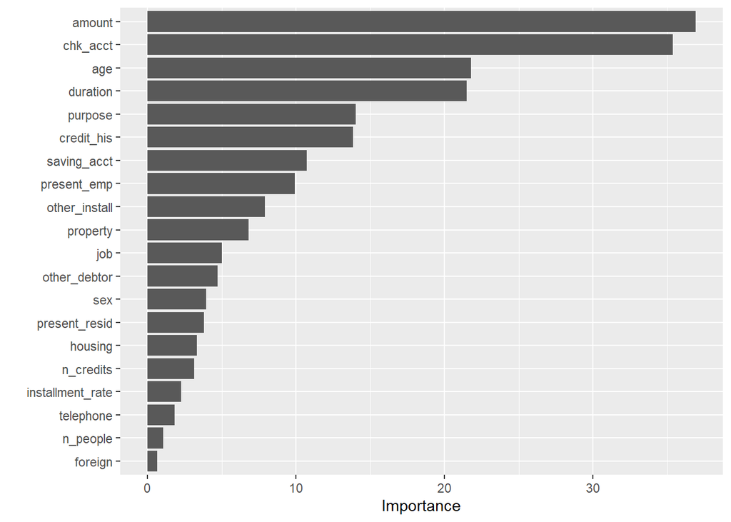

```r
# obtain importance score
last_rf_fit %>%
  pluck(".workflow", 1) %>%
  extract_fit_parsnip() %>%
  vip(num_features = 20)
```

Let’s plot the final ROC curve too.

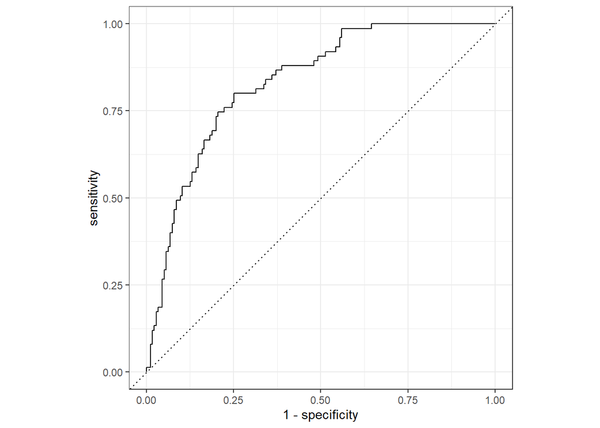

```r
# plot ROC plot
last_rf_fit %>%
  collect_predictions() %>%
  roc_curve(response, .pred_1) %>%
  autoplot()
```